# Curso - R (Pós ADM)

Alan Rodrigo Panosso

09/03/2020

# 1. O que é o R

- O sistema R é um ambiente que incorpora uma implementação da linguagem de programação S, desenvolvida por John Chambers et al na Lucent Technologies em 1960.
- 1988: S-Plus é implementado o Software proprietário de análise de dados que contém a linguagem S.
- 1996: Linguagem orientada a objetos R (Ross Ihaka e Robert Gentleman).
- R é uma poderosa linguagem, flexível e possui excelentes facilidades gráficas.
- R é um projeto **open-source** e está disponível na internet sobre a General Public License (www.gnu.org/copyleft/gpl.html e www.fsf.org).

# 2. Instalação do R (sistema base)

Baixe o R do site oficial The R Project for Statistical Computing https://www.r-project.org/

Acesso rápido: [Download](https://cran-r.c3sl.ufpr.br/bin/windows/base/R-3.6.3-win.exe)

Salve o arquivo de instalação em um diretório de seu computador e em seguida execute-o. O processo é simples e intuitivo.

# 3. Instalando o RStudio

É um ambiente de desenvolvimento integrado (IDE) para o R, disponível em https://rstudio.com/products/rstudio/download/

Escolha a o instalador de acordo com o seu sistema operacional. **Windows** no nosso caso, o na grande maioria…

Novamente, salve o arquivo de instalação em um diretório de seu computador e em seguida execute-o.

Após a instalação procure o ícone do R criado pelo instalador e clique nele.

# 4. Pacotes no R (instalação dos pacotes)

Um pacote é uma coleção de funções, exemplos e documentação. A funcionalidade de um pacote é frequentemente focada em uma metodologia estatística especial" (**Everitt & Hothorn**).

### Utilizando a opção `Install/Packages`

Instale alguns pacotes:

- `tidyverse`
- `agricolae`
- `lawstat`
- `nortest`
- `lattice`
- `readxl`
- `stringr`
- `lubridate`

# 5. Operações Básicas

### operação aritmética

```r
1 + 7 # cálculo da soma destes dois números
1 - 2 * 10 # prioridade da multiplicação
2 ** 10 # potências utilizando ** ou ^
10/3 # divisão
```

### funções encontradas em calculadoras científicas

$$\begin{aligned}
& a)\;\sqrt{9} = 3\\
& b)\;seno\;\pi = 0\\
& c)\;4! = 24\\
& d)\; e^5 = 148.4132
\end{aligned}$$

```r
sqrt(9) # raiz quadrada
sin(pi) # seno de Pi radianos é zero
factorial(4) #4!=4*3*2*1
exp(5) #exponencial de 5, e^5
```

### operações relacionais

$$\begin{aligned}
& a)\;7 > 5 \text{ retorna 'true'}\\
& b)\;8 \leq 4 \text{ retorna 'false'}\\
& c)\;5 = \frac{25}{5} \text{ retorna 'true'}\\
& d)\; 4\neq 8 \text{ retorna 'true'}
\end{aligned}$$

```r
7 > 5 # 7 é maior que 5 ?
8 <= 4 # 8 é menor ou igual a 4?
5 == 25/5 # igual a
4 != 8 # Diferente de
```

**Exercício 1**. Resolva as seguintes expressões:
$$\begin{aligned}
& a)\; log\;3 \\
& b)\; log_4\;3\\
& c)\; ln\;10\\
& d)\; e^2\\
& e)\; \sqrt(225)\\
& f)\; \frac{25+60\times8}{(14-5)^2}\\
& g)\; 8!\\
& h)\; seno\;30°\\
& i)\; \frac{1}{\sqrt{2\pi}}\cdot e^{-\frac{1}{2}\times4^2}\\
& j)\; \text{Gerar 3 números aleatórios}\\
\end{aligned}$$

# 6. Principais objetos no R

## 6.1. Escalar

É um objeto ao qual é atribuído um valor que pode ter qualquer um dos tipos, numérico, caractere, complexo ou lógico.

```r
x <- 10
"Maria" -> nome
res  <- (x==20)
```

```
  Quando uma estrutura de dados é composta de variáveis com o mesmo tipo primitivo, temos um conjunto  de dados homogêneo (vetores, fatores e matrizes).
```

## 6.2. Vetor

É considerada a **forma mais simples de armazenamento de dados** em um objeto, são classificados como variáveis com **um ou mais valores do mesmo tipo**. Na verdade, um escalar para o R é definido como um vetor com um único elemento. Essa estrutura de dados tem o 1 como índice inicial. E podem ser referenciados por **[k]** onde k é a posição do elemento no vetor.

```r
z<-c(3,2,7,4,5)
z[3] # o elemento na posição 3 de z é o inteiro 7.
1:10
seq(0,100,25)
rep(1,10)
rep(1:3,4)
rep("testemunha",4)
x<-1:100
is.vector(x)
is.vector(z)
length(z)
```

```
Um conjunto heterogêneo de dados é composto por elementos que não são do mesmo tipo primitivo, como exemplo, temos os data.frames e as listas (ou registros).
```

## 6.3. Data Frames

Os data.frames são considerados a **melhor forma de armazenar dados**, pois cada linha corresponde a uma unidade (observação), indivíduo ou pessoa, e cada coluna representa uma medida realizada em cada unidade (característica ou variáveis).

```r
alunos<-data.frame(
  RA=c(1933456,1935432,1869524),
  Nome=c("Maria Eduarda Ferreira","Paulo Antunes Arantes","Ricardo Luís Siqueira"),
  Média=c(9.5,7.75,4.8),
  Situação=c("Aprovado","Aprovado","Exame")
)
alunos
```

# 7. Entrada de dados

## 7.1. Lendo diretamente da Internet

```r
dados_usina <- read.table("https://raw.githubusercontent.com/arpanosso/posADM/master/dados_usina.txt",
                          h=TRUE,
                          sep="\t")
```

## 7.2. Banco de dados em TXT

Faça o dowload do banco de dados dados_usina.txt

```r
dados_usina <- read.table("C:/Users/panosso/Desktop/dados_usina.txt",h=TRUE,sep="\t")
```

## 7.3. Banco de dados do Excel

Faça o download do banco de dados dados_usina.xlsx

```r
library(readxl)
dados_usina <- read_excel("C:/Users/panosso/Desktop/dados_usina.xlsx")
```

# 8. Manipulação dos dados

Para a manipulação dos nossos dados, vamos utilizar o pacote `dplyr`, que é um pacote específico para a manipulação de dados, unido ao pacote `ggplot2` é um poderoso recurso para exploração, transformação e visualização de dados. Ambos os pacotes fazem parte o `tidyverse`, que é um pacote de pacotes.

## 5 principais funções (verbos) do `dplyr`.

- `filter()`: seleciona/filtra por linhas (observações) a base de dados
- `arrange()`: ordena a base de dados de acordo com alguma coluna (variável)
- `select()`: seleciona colunas (variáveis)
- `mutate()`: modifica/transforma/cria variáveis (colunas)
- `summarise()`: resume/agrega, variáveis (colunas) de uma base de dados

## Regras para manipulação:

1- O primeiro argumento sempre será um `data.frame`.  
2- Demais argumentos, descrevem como deve ser a manipulação.  
3- A resposta semrpe será um `data.frame`.  
4- Manipulação é realizada com o operador “PIPE” (`%>%`) - `CTRL SHIFT + M`.

### Carregando os pacotes

```r
library(tidyverse)
```

```r
library(ggplot2)
library(lubridate) # manipulação de datas
```

**Exercício 2**. Execute a função `glimpse` para uma visão rápida a respeito das variáveis do banco de dados.

```
## Observations: 1,433
## Variables: 17
## $ Ano              <dbl> 2012, 2012, 2012, 2012, 2012, 2012, 2012, 201...
## $ Gleba            <dbl> 1760, 1756, 1762, 1265, 1749, 1697, 1696, 170...
## $ broca            <dbl> 5.77, 4.70, 4.58, 4.23, 4.16, 4.09, 4.00, 3.9...
## $ grupo_infestacao <chr> "MUITOALTO", "MUITOALTO", "MUITOALTO", "MUITO...
## $ amb_prod         <chr> "D", "A", "B", "A", "B", "B", "B", "A", "A", ...
## $ variedade        <chr> "RB855156", "RB855156", "RB855156", "RB855453...
## $ vinhaca          <dbl> 0.0, 0.0, 0.0, 294.0, 599.9, 685.3, 125.6, 0....
## $ solo             <chr> "LVE.5", "LR.1", "LR.2", "LR.1", "LVA.2", "LR...
## $ tch              <dbl> 87.60, 114.00, 96.25, 90.29, 90.73, 115.05, 7...
## $ fazenda          <chr> "APARECIDA", "APARECIDA", "APARECIDA", "APARE...
## $ data_plantio     <dttm> 2011-04-29, 2011-11-07, 2011-11-07, 2011-05-...
## $ data_avaliacao   <dttm> 2012-05-25, 2012-11-19, 2012-05-25, 2012-06-...
## $ chuva            <dbl> 1326.3, 1477.7, 1046.8, 1357.2, 1334.8, 1275....
## $ tmed             <dbl> 22.20616, 22.68462, 23.46179, 22.20290, 22.23...
## $ ur               <dbl> 67.06985, 67.94707, 71.84418, 67.41023, 67.12...
## $ etp              <dbl> 1406.07, 1393.25, 780.70, 1381.91, 1408.47, 1...
## $ rad              <dbl> 7144.84, 6829.10, 3808.55, 6999.53, 7147.57, ...
```

**Exercício 3**. Selecione as **linhas** com produção de cana por hectare (tch) maiores que 90$ t;ha^{-1}$.

```r
dados_usina %>%
  filter(tch> 90)
```

**Exercício 4**. Crie outro banco de dados `svin` para aqueles registros onde não houve a aplicação de vinhaça no ano de 2014.

```r
svin<-dados_usina %>%
  filter(vinhaca == 0,Ano == 2014)
```

**Exercício 5**. De `svin` selecione todas as glebas que não pertencem à fazenda “SÃO BENTO”.

```r
svin %>%
  filter(fazenda != "SÃO BENTO")
```

**Exercício 6**. De `svin` selecione todas as glebas que pertencen às fazendas “APARECIDA” ou “CARABOLANTE” e faça uma contagem de quantas glebas existem em cada fazenda.

```r
svin %>%
  filter(fazenda == "APARECIDA" | fazenda == "CARABOLANTE") %>%
  count(fazenda)
```

**Exercício 7**. Selecione os registros cuja variedade é CTC?

```r
library(stringr)
dados_usina %>%
  filter(str_detect(variedade,"CTC"))
levels(as.factor(dados_usina$variedade))
```

**Exercício 8**. Selecione os registros cuja variedade é SP?

```r
dados_usina %>%
  filter(str_detect(variedade,"^SP"))
```

**Exercício 9**. Selecione os registros cujo nome da variedade termina com o número “5”?

```r
dados_usina %>%
  filter(str_detect(variedade,"5$"))
```

**Exercício 10**. Selecione os registros que apresentam data de plantio superior a 01/01/2013?

```r
library(lubridate)
dados_usina %>%
  filter(data_plantio > ymd("2013-01-01"))
```

```
## # A tibble: 794 x 17
##      Ano Gleba broca grupo_infestacao amb_prod variedade vinhaca solo
##    <dbl> <dbl> <dbl> <chr>            <chr>    <chr>       <dbl> <chr>
##  1  2014  4248  4.67 MUITOALTO        D        RB867515    1380. LVA.8
##  2  2014  4235  4.17 MUITOALTO        D        SP83-2847   1360. LVA.8
##  3  2014  4237  3.84 MUITOALTO        D        CTC2        1148  LVA.8
##  4  2014  4234  3.08 MUITOALTO        B        RB855453     739. LR.2
##  5  2014  4032  3.04 MUITOALTO        B        SP80-1816    676. LR.2
##  6  2014  4482  3.01 MUITOALTO        B        RB855156     600. LVA.2
##  7  2014  4042  2.76 MUITOALTO        A        CTC14       1756. LR.1
##  8  2014  2370  2.74 MUITOALTO        A        RB855453     294  LR.1
##  9  2014  4193  2.49 ALTO             A        RB855453       0  LR.1
## 10  2014  4497  2.47 ALTO             A        SP80-1816      0  LR.1
## # ... with 784 more rows, and 9 more variables: tch <dbl>, fazenda <chr>,
## #   data_plantio <dttm>, data_avaliacao <dttm>, chuva <dbl>, tmed <dbl>,
## #   ur <dbl>, etp <dbl>, rad <dbl>
```

**Exercício 11**. Ordene os registro por ordem crescente de data da coleta

```r
dados_usina %>%
  arrange(data_avaliacao)
```

**Exercício 12**. Ordene os registro por ordem crescente decrescente de intensidade de infestação da broca

```r
dados_usina %>%
  arrange(desc(broca))
```

**Exercício 13**. Calcule a idade da cana no momento da avaliação, em dias.

```r
dados_usina %>%
  mutate(
    idade_dias = difftime(data_avaliacao,data_plantio,units = "days"),
    idade_anos = idade_dias/365
  )
```

```r
dados_usina %>%
  mutate(
    prod = case_when(
      tch < 50 ~ "Baixa",
      tch <= 90 ~ "Media",
      tch <= 500 ~ "Alta",
      TRUE ~ "Sem classificação")
  )
```

# 9. Estatística Básica

**Exercício 15**. Calcule as estatísticas descrivas produção da cana-de-açúcar para o banco de dados.

```r
library(agricolae)
dados_usina %>%
  group_by(fazenda) %>%
  summarise(N=length(tch),
            media = mean(tch),
            mediana =median(tch),
            minimo=min(tch),
            maximo=max(tch),
            variancia = var(tch),
            desv_pad = sd(tch),
            epm= desv_pad/sqrt(N),
            cv=round(100*sd(tch)/mean(tch),2),
            assimetria = skewness(tch),
            curtosi = kurtosis(tch)
            )
```

## 9.1 Gráficos usando o ggplot

**Exercício 16**. Construa um gráfico de dispersão entre a chuva e temperatura do ar.

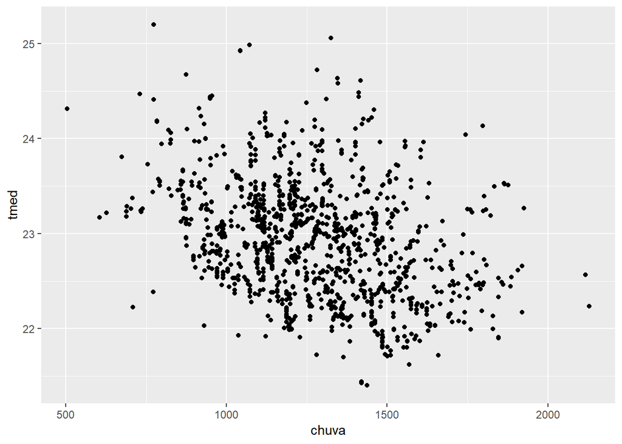

```r
# chamar os dados
# filtrar, agrupar, gerar estatísticas se necessário
# adicionar as camadas gráficas

# Gráfico de Dispersão
dados_usina %>%
  ggplot(aes(x=chuva,y=tmed) ) + # dizer quem será o x e o y dentro de aes
  geom_point()
```

**Exercício 17**. Construa um gráfico de dispersão entre a chuva e temperatura do ar, mapeie os anos por meio das cores no novo gráfico.

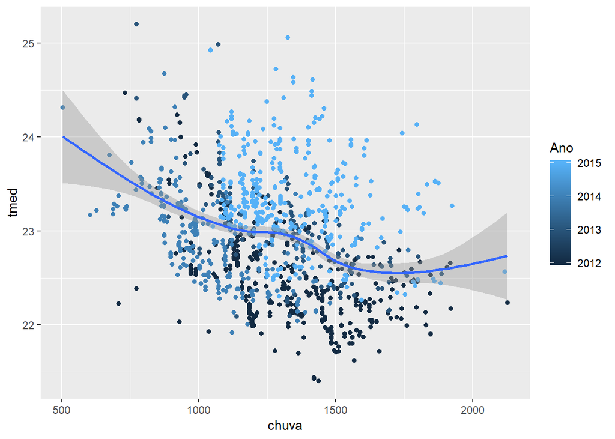

```r
# Gráfico de Dispersão
dados_usina %>%
  ggplot(aes(x=chuva,y=tmed,color=Ano) ) + # dizer quem será o x e o y dentro de aes
  geom_point()+
  geom_smooth(aes(x=chuva,y=tmed))
```

**Exercício 18**. Construa um gráfico de dispersão entre a chuva e temperatura do ar, mapeie os anos por meio das formas no novo gráfico.

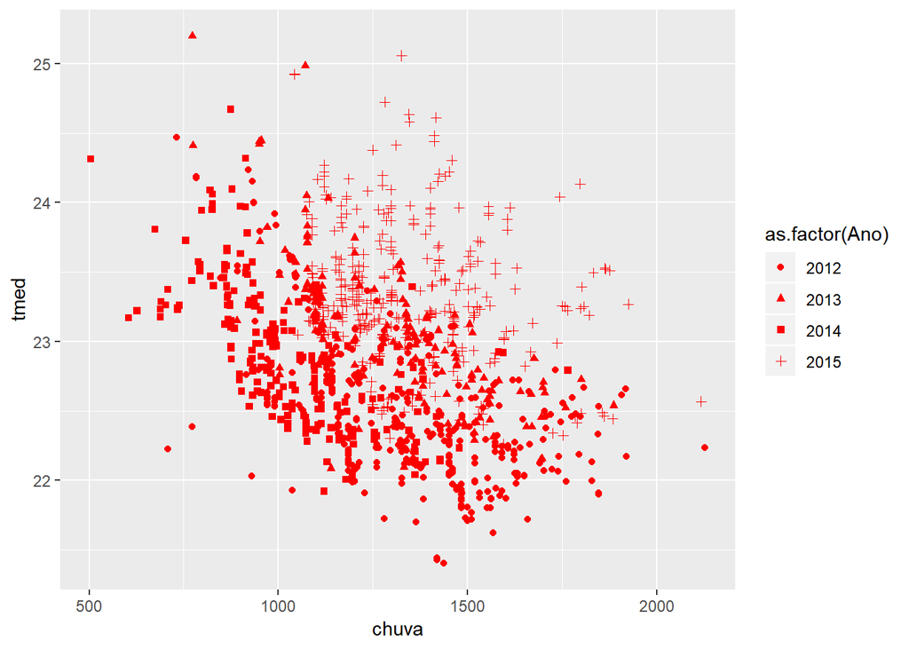

```r
dados_usina %>%
  ggplot(aes(x=chuva,y=tmed)) +
  geom_point(aes(shape=as.factor(Ano)),color="red")
```

**Exercício 18**. Adicione os títulos dos gráficos, eixos e legendas.

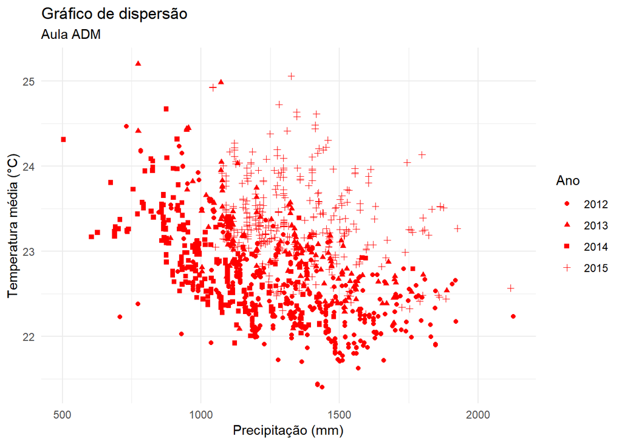

```r
dados_usina %>%
  ggplot(aes(x=chuva,y=tmed) ) + # dizer quem será o x e o y dentro de aes
  geom_point(aes(shape=as.factor(Ano)),color="red")+
  theme_minimal()+
  labs(x="Precipitação (mm)",y="Temperatura média (°C)",shape="Ano") +
  ggtitle("Gráfico de dispersão",subtitle = "Aula ADM")
```

**Exercício 19**. Criar um gráfico de barras, com as principais variedades plantadas no período para a fazenda MODELO.

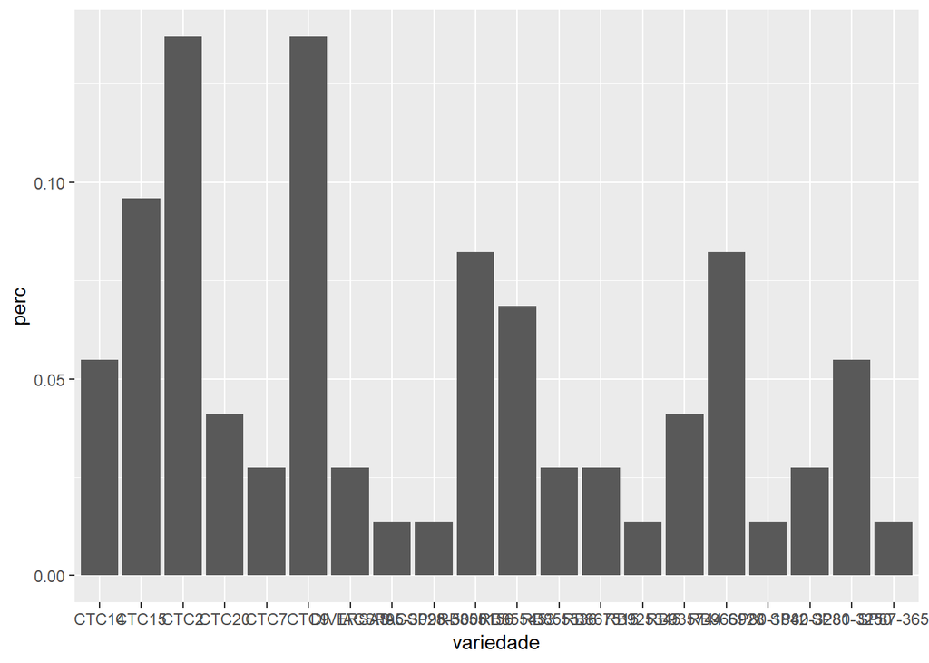

```r
dados_usina %>%
  filter(fazenda=="MODELO") %>%
  group_by(variedade) %>%
  summarise(n=n()) %>%
  mutate(perc=n/sum(n)) %>%
  ggplot(aes(x=variedade, y=perc))+
  geom_col()
```

**Exercício 20**. Altere os eixos as cores do gráfico anterior.

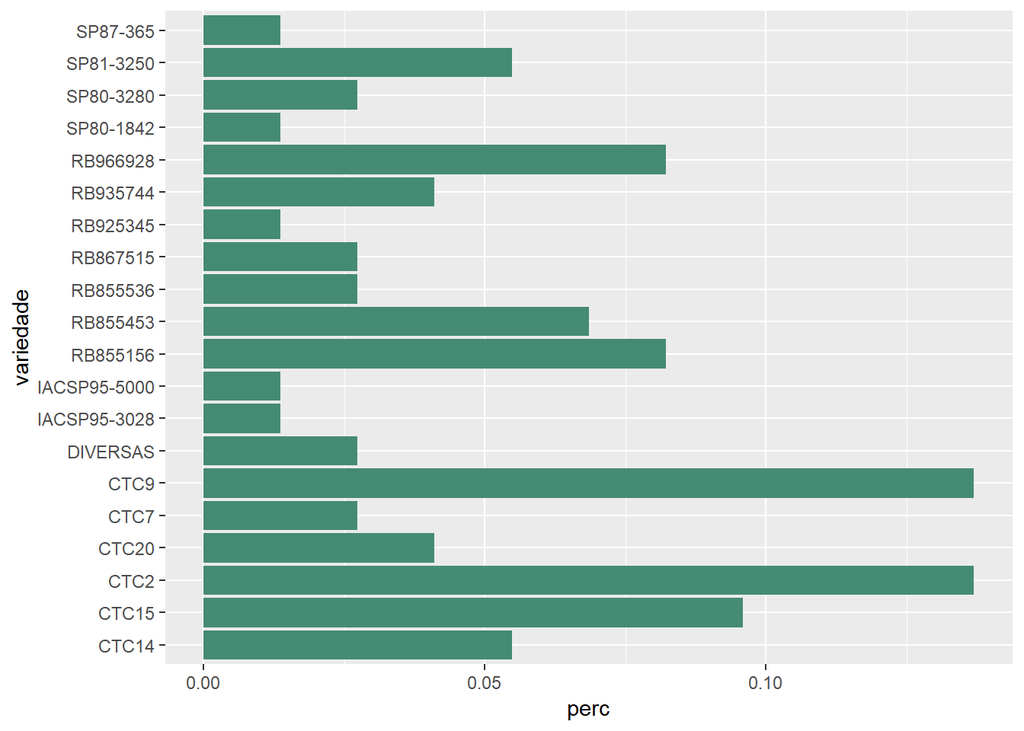

```r
# Gráfico de Barras
# Variedaeres plantadas na fazenda modelo
dados_usina %>%
  filter(fazenda=="MODELO") %>%
  group_by(variedade) %>%
  summarise(n=n()) %>%
  mutate(perc=n/sum(n)) %>%
  ggplot(aes(x=variedade, y=perc))+
  geom_col(fill="aquamarine4") +
  coord_flip()
```

**Exercício 21**. Ordene o banco de dados das variedades mais plantadas para as menos plantadas.

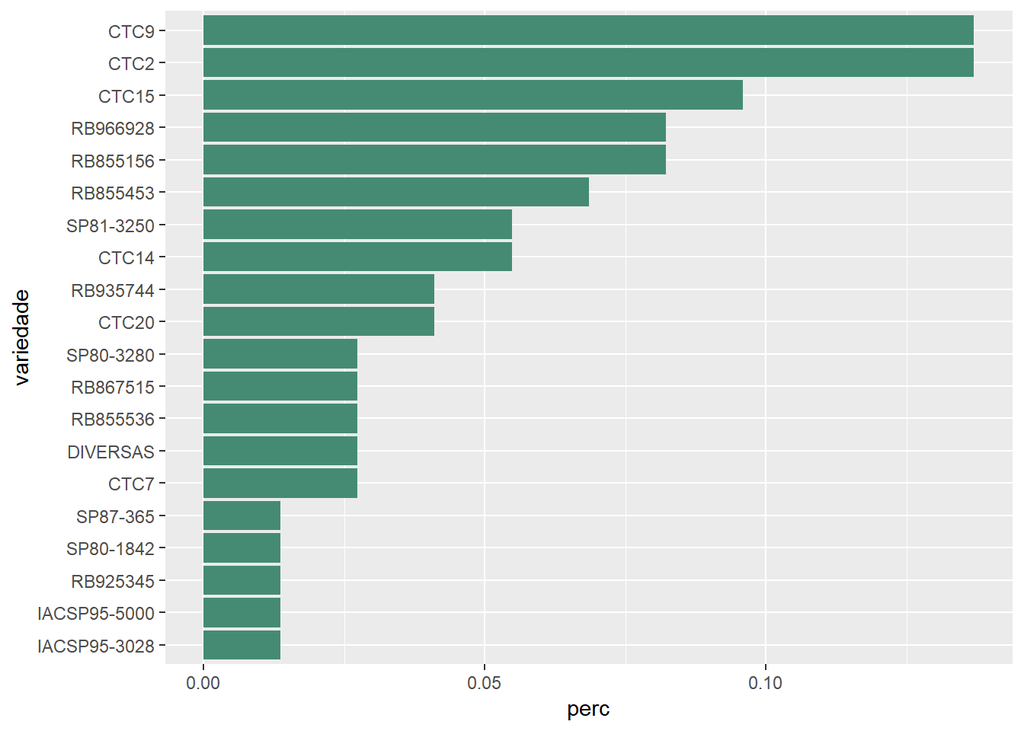

```r
# Gráfico de Barras
# 20 Variedaeres plantadas na fazenda modelo
dados_usina %>%
  filter(fazenda=="MODELO") %>%
  group_by(variedade) %>%
  summarise(n=n()) %>%
  mutate(perc=n/sum(n),
         variedade = variedade %>% fct_lump(n=20,w=perc) %>% fct_reorder(perc)) %>%
  ggplot(aes(x=variedade, y=perc))+
  geom_col(fill="aquamarine4") +
  coord_flip()
```

**Exercício 22**. Mostre as 30 variedades mais plantas na usina como um todo.

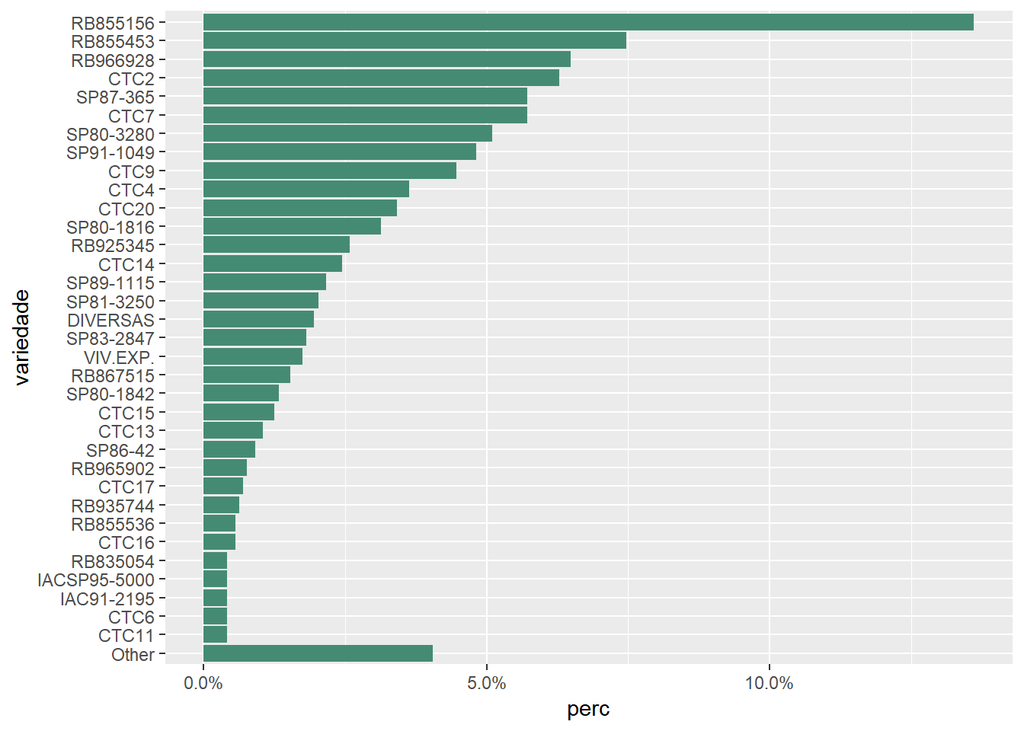

```r
# Gráfico de Barras
# 30 Variedaeres plantadas na usina
dados_usina %>%
  group_by(variedade) %>%
  summarise(n=n()) %>%
  mutate(perc=n/sum(n),
         variedade = variedade %>% fct_lump(n=30,w=perc) %>% fct_reorder(perc)) %>%
  ggplot(aes(x=variedade, y=perc))+
  geom_col(fill="aquamarine4") +
  coord_flip() +
  scale_y_continuous(labels = scales::percent_format())
```

**Exercício 23**. Criar o gráfico de colunas par as médias de produção de cana por ano para cada fazenda pertencente à usina.

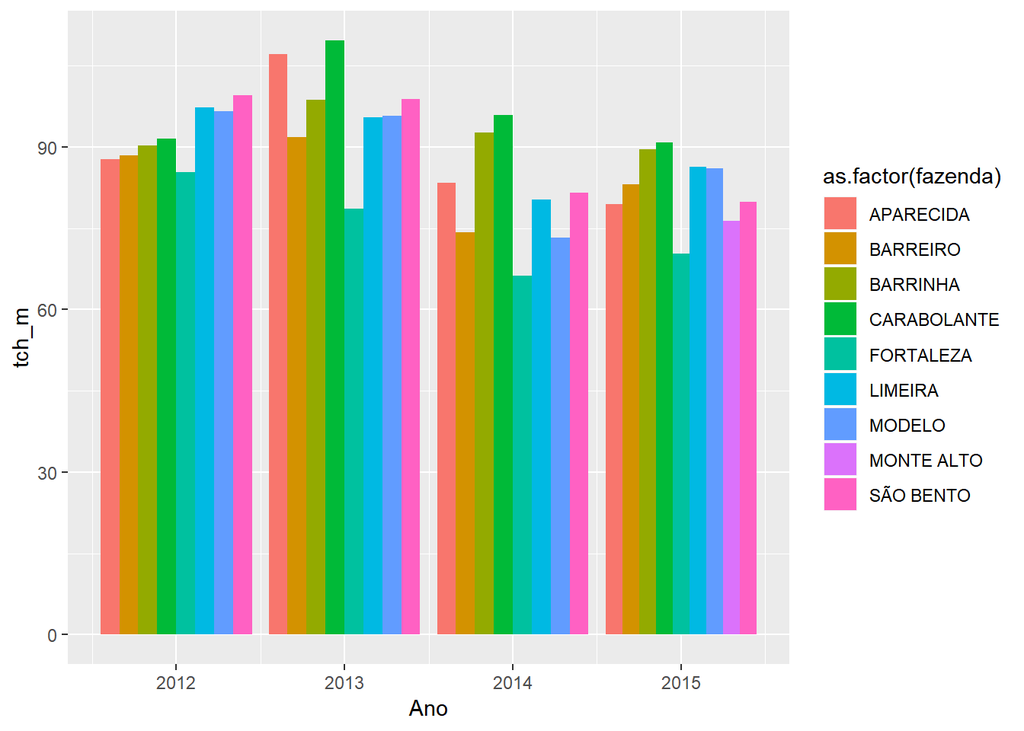

```r
# Gráfico das médias por ano em cada fazenda
dados_usina %>%
  group_by(Ano,fazenda) %>%
  summarise(tch_m=mean(tch)) %>%
  ggplot(aes(x=Ano,y=tch_m,fill=as.factor(fazenda))) +
#  geom_col(position = "stack") +
  geom_col(position = "dodge")
```

```r
#  facet_wrap(~fazenda)
```

**Exercício 24**. Adicione a linha de tendência linear para cada fazenda.

```
## geom_path: Each group consists of only one observation. Do you need to
## adjust the group aesthetic?
```

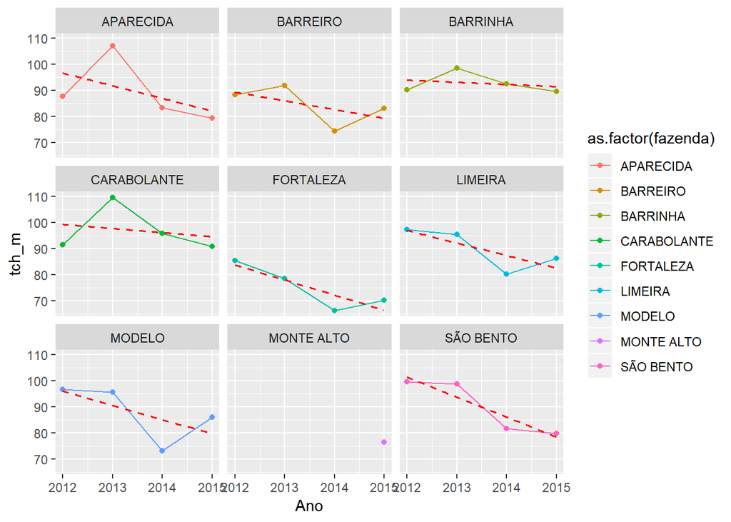

```r
# Gráfico das médias por ano em cada fazenda
dados_usina %>%
  group_by(Ano,fazenda) %>%
  summarise(tch_m=mean(tch)) %>%
  ggplot(aes(x=Ano,y=tch_m,color=as.factor(fazenda))) +
  geom_line()+
  geom_point()+
  facet_wrap(~fazenda)+
    geom_smooth(mapping = aes(x=Ano, y=tch_m),
              method="lm",
              color="red",lwd=.6,lty=2,
              se=FALSE)
```

**Exercício 25**. Construa o gráfico de distribuição de frequência para as variáveis contínuas do banco de dados.

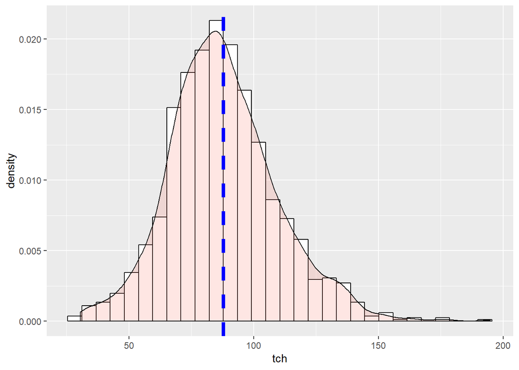

```r
# Hitograma das variáveis contínuas
dados_usina %>%
  ggplot(aes(x=tch))+
  geom_histogram(aes(y=..density..),color="black",fill="white",bins=30)+
  geom_density(alpha=.2,fill="salmon")+
  geom_vline(aes(xintercept=mean(tch)),color="blue",size=1.6,linetype="dashed")
```

**Exercício 26**. Construa o gráfico de distribuição de frequência para tch em cada fazenda, de maneira indepentende do ano

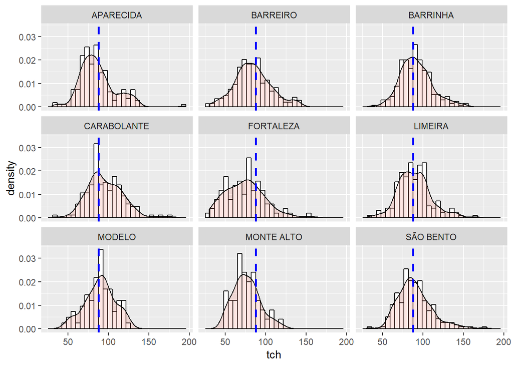

```r
dados_usina %>%
  group_by(fazenda) %>%
  ggplot(aes(x=tch))+
  geom_histogram(aes(y=..density..),color="black",fill="white",bins=30)+
  geom_density(alpha=.2,fill="salmon")+
  geom_vline(aes(xintercept=mean(tch)),color="blue",size=1,linetype="dashed")+
  facet_wrap(~fazenda)
```

## Exemplo de Violin plot

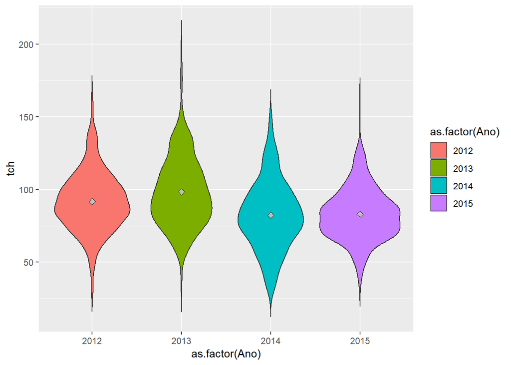

```r
# Gráficos Violino
dados_usina %>%
  ggplot(aes(y=tch,x=as.factor(Ano),fill=as.factor(Ano))) +
  geom_violin(trim = FALSE) +
  stat_summary(fun.y = mean, geom = "point",shape=23,size=2,color="black",fill="gray")
```

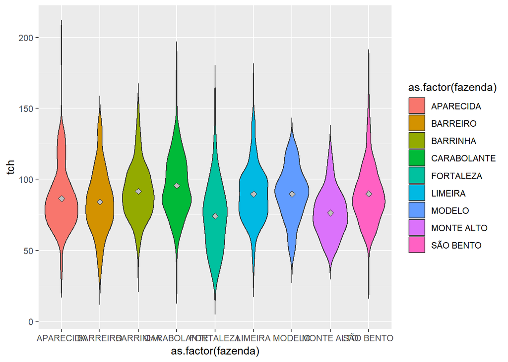

```r
dados_usina %>%
  ggplot(aes(y=tch,x=as.factor(fazenda),fill=as.factor(fazenda))) +
  geom_violin(trim = FALSE) +
  stat_summary(fun.y = mean, geom = "point",shape=23,size=2,color="black",fill="gray")
```

# 10. Alguns testes inferenciais

## 10.1. Testes de comparação de médias

**Exercício 27**. Para o ano de 2015, verifique se as variâncias da produção de cana-de-açúcar são semelhantes para glebas que recebram ou não vinhaça.

```r
da<-dados_usina %>%
  filter(Ano==2015) %>%
  mutate(
    vin = if_else(vinhaca==0,0,1)
  )
var.test(da$tch~da$vin)
```

```
##
##  F test to compare two variances
##
## data:  da$tch by da$vin
## F = 1.204, num df = 288, denom df = 199, p-value = 0.1598
## alternative hypothesis: true ratio of variances is not equal to 1
## 95 percent confidence interval:
##  0.9291307 1.5508146
## sample estimates:
## ratio of variances
##           1.204029
```

**Exercício 28**. Para o ano de 2015, verifique se a produção de cana-de-açúcar foi maior nas glebas que recebram vinhaça.

```r
da<-dados_usina %>%
  filter(Ano==2015) %>%
  mutate(
    vin = if_else(vinhaca==0,0,1)
  )
t.test(da$tch~da$vin,var.equal=TRUE)
```

```
##
##  Two Sample t-test
##
## data:  da$tch by da$vin
## t = -4.813, df = 487, p-value = 1.987e-06
## alternative hypothesis: true difference in means is not equal to 0
## 95 percent confidence interval:
##  -10.976421  -4.612454
## sample estimates:
## mean in group 0 mean in group 1
##        79.88671        87.68115
```

## 10.3. Normalidade

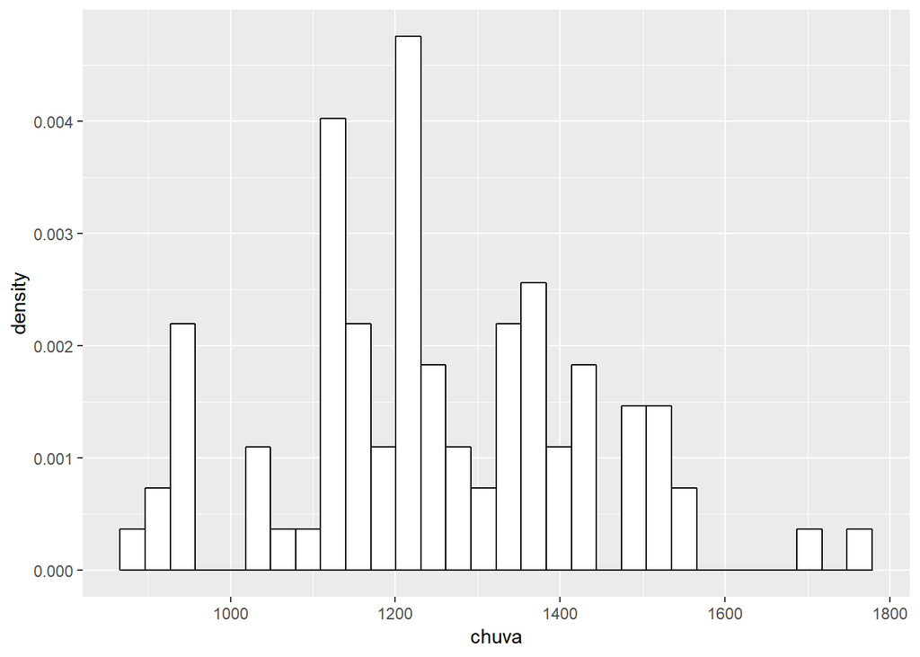

```r
# TCH e CHUVA
library(nortest)
da<-dados_usina %>%
  filter(fazenda=="FORTALEZA")
da %>%
  ggplot(aes(x=chuva)) +
  geom_histogram(aes(y=..density..),color="black",fill="white",bins=30)
```

```r
shapiro.test(da$tch)
```

```
##
##  Shapiro-Wilk normality test
##
## data:  da$tch
## W = 0.97691, p-value = 0.1094
```

```r
cvm.test(da$tch)
```

```
##
##  Cramer-von Mises normality test
##
## data:  da$tch
## W = 0.041597, p-value = 0.648
```

```r
lillie.test(da$tch)
```

```
##
##  Lilliefors (Kolmogorov-Smirnov) normality test
##
## data:  da$tch
## D = 0.058894, p-value = 0.6186
```

```r
ad.test(da$tch)
```

```
##
##  Anderson-Darling normality test
##
## data:  da$tch
## A = 0.34143, p-value = 0.487
```

## 10.4. Homocedasticidade e normalidade do erros na Análise de Variância

```r
# FORTALEZA E CARABOLANTE
da<-dados_usina %>%
  filter(fazenda=="CARABOLANTE")
mod<-aov(tch~Ano,data=da)
anova(mod)
```

```
## Analysis of Variance Table
##
## Response: tch
##            Df Sum Sq Mean Sq F value Pr(>F)
## Ano         1   1146 1146.29  2.4263 0.1214
## Residuals 149  70394  472.44
```

```r
library(lawstat)
levene.test(da$tch,da$Ano)
```

```
##
##  Modified robust Brown-Forsythe Levene-type test based on the
##  absolute deviations from the median
##
## data:  da$tch
## Test Statistic = 0.24263, p-value = 0.8665
```

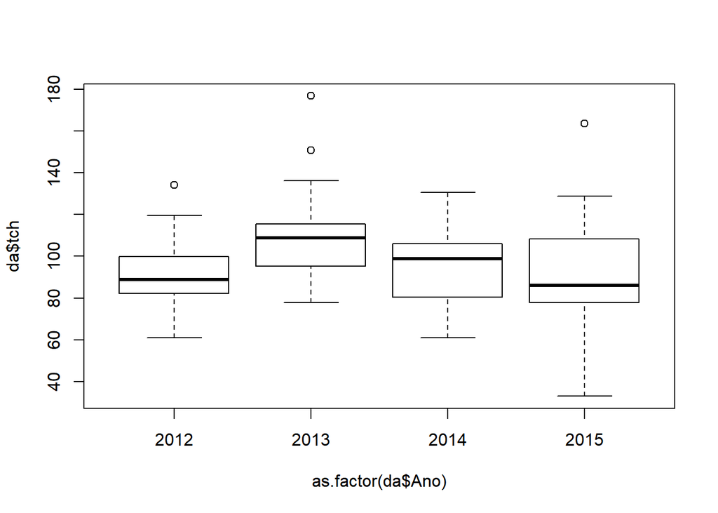

```r
plot(da$tch~as.factor(da$Ano))
```

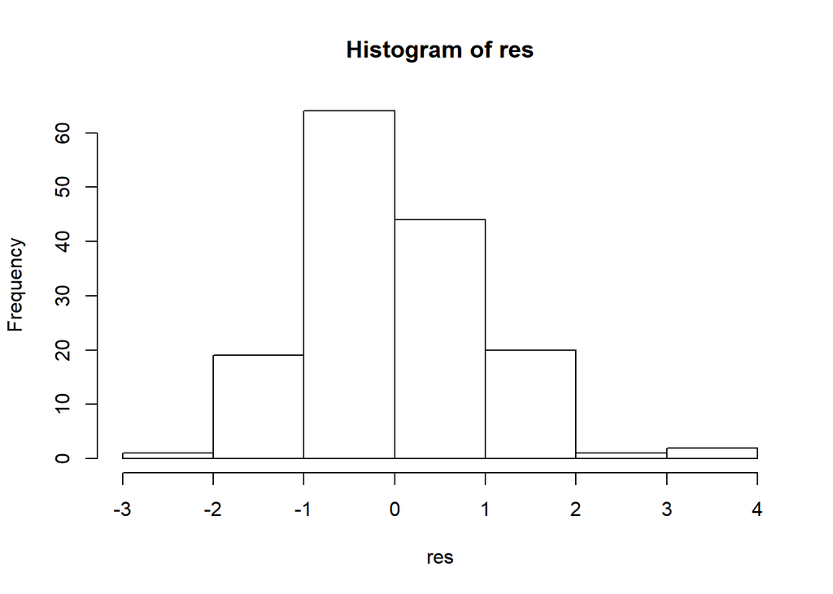

```r
res<-rstudent(mod)
hist(res)
```

```r
shapiro.test(res)
```

```
##
##  Shapiro-Wilk normality test
##
## data:  res
## W = 0.97658, p-value = 0.01113
```

```r
ad.test(res)
```

```
##
##  Anderson-Darling normality test
##
## data:  res
## A = 0.71586, p-value = 0.06055
```

```r
lillie.test(res)
```

```
##
##  Lilliefors (Kolmogorov-Smirnov) normality test
##
## data:  res
## D = 0.06467, p-value = 0.1272
```

```r
cvm.test(res)
```

```
##
##  Cramer-von Mises normality test
##
## data:  res
## W = 0.11663, p-value = 0.06587
```

# Referências

CHANG, W. R Graphics Cookbook. USA: O’Reilly Media, Inc, 2013. 397 p.

TEETOR, P. R Cookbook. USA: O’Reilly Media, Inc, https://rc2e.com/.